# Forecasting Project 1 - Group 7

## 5.2 Italy

We fit Italy electricity demand data using the ARIMA model.

```r
# Modelling ETS automatically
arima_italy <- data_elec %>%
  select(Italy) %>%
  model(ARIMA(Italy))

# Forecasting using the models
forecast_arima_italy <- arima_italy %>% forecast(h = 13) %>% hilo(90)
```

### **Checking Residuals**

The output below suggests that the ARIMA model did well in capturing all the dynamics in data, as the residuals seem to be white noise.

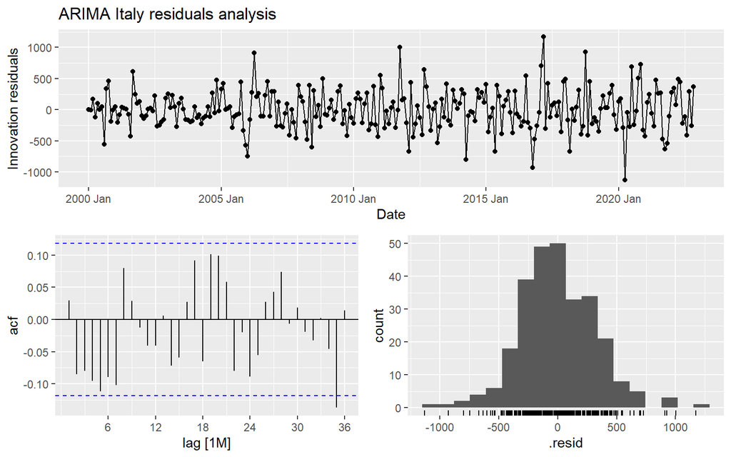

```r
arima_italy %>% gg_tsresiduals(lag_max = 36) + labs(title = "ARIMA Italy residuals analysis")
```

### **Graphing the forecast**

For better visualization, we plot our forecast results starting from 2018.

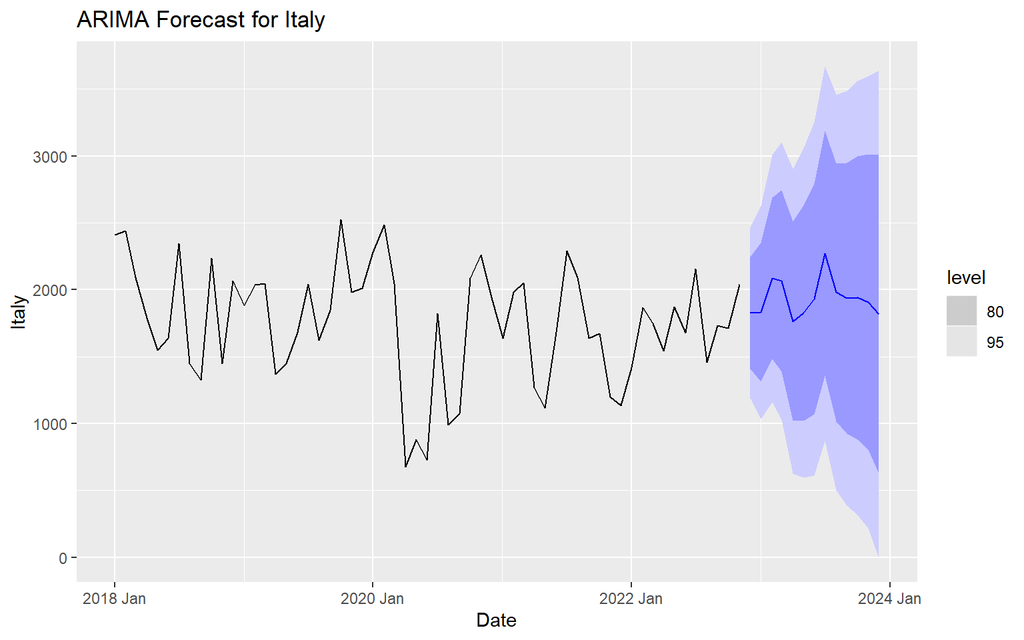

```r
arima_italy %>% forecast(h = 13) %>% autoplot(Italy_since_2018) +
  labs(title = "ARIMA Forecast for Italy")
```

```r
#Extracting the forecasted values
forecast_table_italy_a <- data.frame(Model = c("ARIMA"),
                          Forecast_Values = c(forecast_arima_italy))

forecast_table_italy_a <- forecast_table_italy_a %>% select(Forecast_Values.Date,Forecast_Values..mean, Forecast_Values.90.)
forecast_table_italy_a$Country <- "Italy"

colnames(forecast_table_italy_a)[1] <- "Month"
colnames(forecast_table_italy_a)[2] <- "PF"
colnames(forecast_table_italy_a)[3] <- "CI"
```

### **Forecast Table**

The resulting forecast table for Italy is shown below.

```r
#forecast_table_italy_a
kbl(forecast_table_italy_a) %>%
  kable_styling(fixed_thead = T)
```

| Month | PF | CI | Country |
| --- | --- | --- | --- |
| 2022 Dec | 1826.559 | [1289.9394, 2363.178]90 | Italy |
| 2023 Jan | 1830.641 | [1164.2666, 2497.015]90 | Italy |
| 2023 Feb | 2084.348 | [1309.6550, 2859.040]90 | Italy |
| 2023 Mar | 2064.941 | [1195.3191, 2934.564]90 | Italy |
| 2023 Apr | 1763.042 | [807.8790, 2718.206]90 | Italy |
| 2023 May | 1826.055 | [792.4052, 2859.704]90 | Italy |
| 2023 Jun | 1930.824 | [824.2409, 3037.406]90 | Italy |
| 2023 Jul | 2272.030 | [1097.0320, 3447.028]90 | Italy |
| 2023 Aug | 1978.937 | [739.2947, 3218.580]90 | Italy |
| 2023 Sep | 1936.262 | [635.1825, 3237.342]90 | Italy |
| 2023 Oct | 1939.172 | [579.4288, 3298.916]90 | Italy |
| 2023 Nov | 1906.992 | [491.0130, 3322.971]90 | Italy |
| 2023 Dec | 1816.285 | [288.3433, 3344.226]90 | Italy |

## 5.3 Austria

We fit Austria electricity demand data using the ETS model.

```r
# Modelling ETS automatically
ets_austria <- data_elec %>%
  select(Austria) %>%
  model(ETS(Austria))

# Forecasting using the models
forecast_ets_austria <- ets_austria %>% forecast(h = 13) %>% hilo(90)
```

### **Checking Residuals**

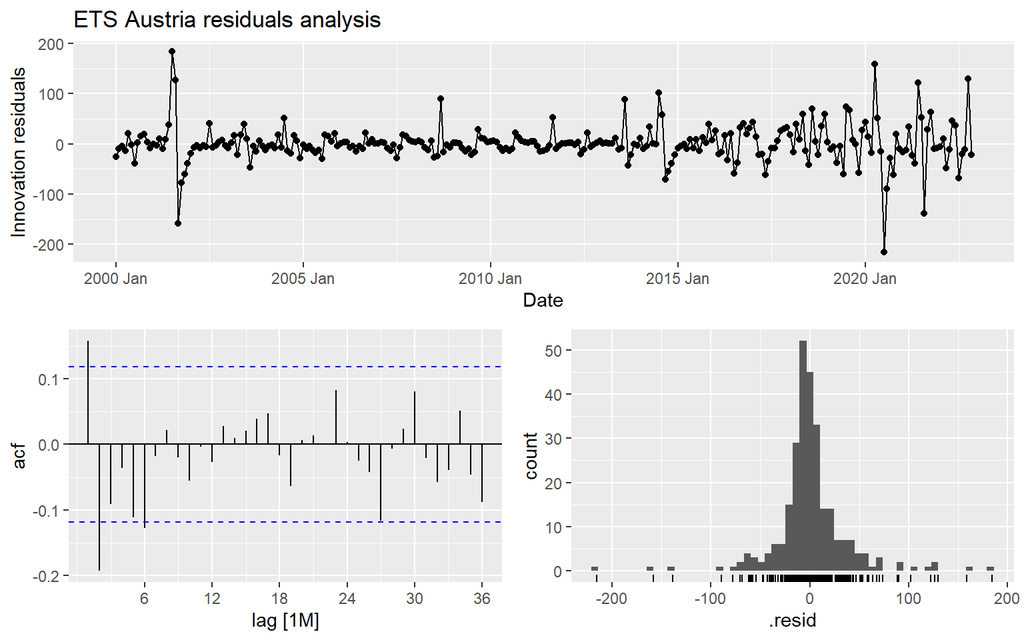

```r
ets_austria %>% gg_tsresiduals(lag_max = 36) + labs(title = "ETS Austria residuals analysis")
```

### **Graphing the forecast**

For better visualization, we plot our forecast results starting from 2018.

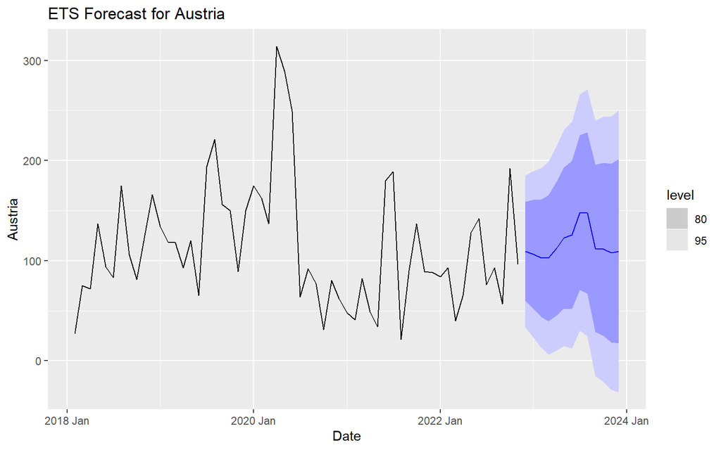

```r
ets_austria %>% forecast(h = 13) %>% autoplot(Austria_since_2018) +
  labs(title = "ETS Forecast for Austria")
```

```r
#Extracting the forecasted values
forecast_table_austria_e <- data.frame(Model = c("ETS"),
                          Forecast_Values = c(forecast_ets_austria))

forecast_table_austria_e <- forecast_table_austria_e %>% select(Forecast_Values.Date,Forecast_Values..mean, Forecast_Values.90.)
forecast_table_austria_e$Country <- "Austria"

colnames(forecast_table_austria_e)[1] <- "Month"
colnames(forecast_table_austria_e)[2] <- "PF"
colnames(forecast_table_austria_e)[3] <- "CI"
```

### **Forecast Table**

The resulting forecast table for Austria is shown below.

```r
#forecast_table_austria_e
kbl(forecast_table_austria_e) %>%
  kable_styling(fixed_thead = T)
```

| Month | PF | CI | Country |
| --- | --- | --- | --- |
| 2022 Dec | 109.2886 | [45.7111685, 172.8659]90 | Austria |
| 2023 Jan | 106.3760 | [36.6047883, 176.1473]90 | Austria |
| 2023 Feb | 102.6006 | [27.1422181, 178.0590]90 | Austria |
| 2023 Mar | 102.4725 | [21.7264929, 183.2184]90 | Austria |
| 2023 Apr | 111.9032 | [26.1952715, 197.6112]90 | Austria |
| 2023 May | 122.5810 | [32.1830104, 212.9790]90 | Austria |
| 2023 Jun | 125.5234 | [30.6669550, 220.3798]90 | Austria |
| 2023 Jul | 148.0999 | [48.9853517, 247.2144]90 | Austria |
| 2023 Aug | 147.6801 | [44.4830307, 250.8771]90 | Austria |
| 2023 Sep | 112.2665 | [5.1423886, 219.3906]90 | Austria |
| 2023 Oct | 111.3402 | [0.4280154, 222.2524]90 | Austria |
| 2023 Nov | 107.7202 | [-6.8564988, 222.2970]90 | Austria |
| 2023 Dec | 109.2886 | [-8.8375275, 227.4146]90 | Austria |

## 5.4 France

We fit France electricity demand data using the ETS model.

```r
# Modelling ETS automatically
ets_france <- data_elec %>%
  select(France) %>%
  model(ETS(France))

# Forecasting using the models
forecast_ets_france <- ets_france %>% forecast(h = 13) %>% hilo(90)
```

### **Checking Residuals**

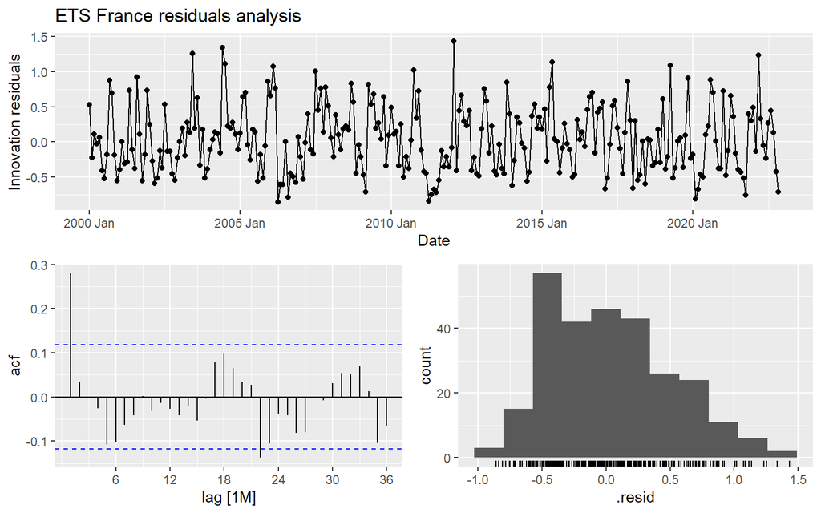

```r
ets_france %>% gg_tsresiduals(lag_max = 36) + labs(title = "ETS France residuals analysis")
```

### **Graphing the forecast**

For better visualization, we plot our forecast results starting from 2015.

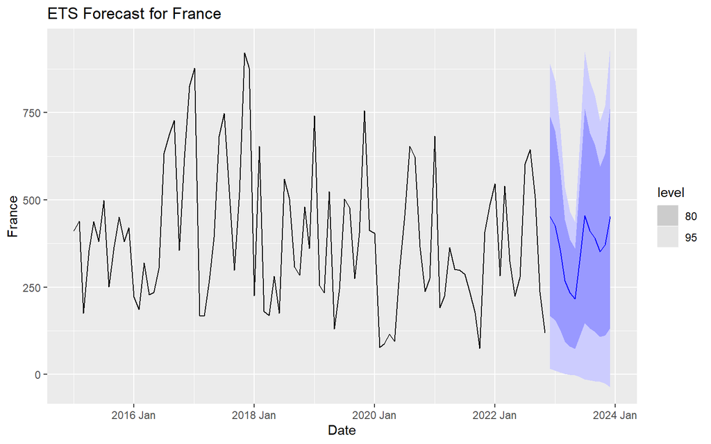

```r
ets_france %>% forecast(h = 13) %>% autoplot(France_since_2015) +
  labs(title = "ETS Forecast for France")
```

```r
#Extracting the forecasted values
forecast_table_france_e <- data.frame(Model = c("ETS"),
                          Forecast_Values = c(forecast_ets_france))

forecast_table_france_e <- forecast_table_france_e %>% select(Forecast_Values.Date,Forecast_Values..mean, Forecast_Values.90.)
forecast_table_france_e$Country <- "France"

colnames(forecast_table_france_e)[1] <- "Month"
colnames(forecast_table_france_e)[2] <- "PF"
colnames(forecast_table_france_e)[3] <- "CI"
```

### **Forecast Table**

The resulting forecast table for France is shown below.

```r
#forecast_table_france_e
kbl(forecast_table_france_e) %>%
  kable_styling(fixed_thead = T)
```

| Month | PF | CI | Country |
| --- | --- | --- | --- |
| 2022 Dec | 452.6419 | [86.27746, 819.0064]90 | France |
| 2023 Jan | 426.1098 | [77.66769, 774.5518]90 | France |
| 2023 Feb | 356.1703 | [61.96845, 650.3721]90 | France |
| 2023 Mar | 268.4822 | [44.50058, 492.4638]90 | France |
| 2023 Apr | 232.8623 | [36.68973, 429.0349]90 | France |
| 2023 May | 216.6737 | [32.37475, 400.9727]90 | France |
| 2023 Jun | 336.6541 | [47.57567, 625.7324]90 | France |
| 2023 Jul | 454.1439 | [60.52136, 847.7665]90 | France |
| 2023 Aug | 411.5258 | [51.54458, 771.5071]90 | France |
| 2023 Sep | 389.8002 | [45.71607, 733.8843]90 | France |
| 2023 Oct | 351.4656 | [38.43236, 664.4988]90 | France |
| 2023 Nov | 371.7370 | [37.71470, 705.7594]90 | France |
| 2023 Dec | 452.6433 | [42.36154, 862.9251]90 | France |

## 5.5 Lichtenstein

We fit Lichtenstein electricity demand data using the SNaive model.

### **Checking Residuals**

As expected the SNaive is a relatively simple model, it hardly capture all the dynamics in data, since the residuals are not white noise. Also, it is not surprising to observe correlation between ts and lags, since it is inherent from a Naive models.

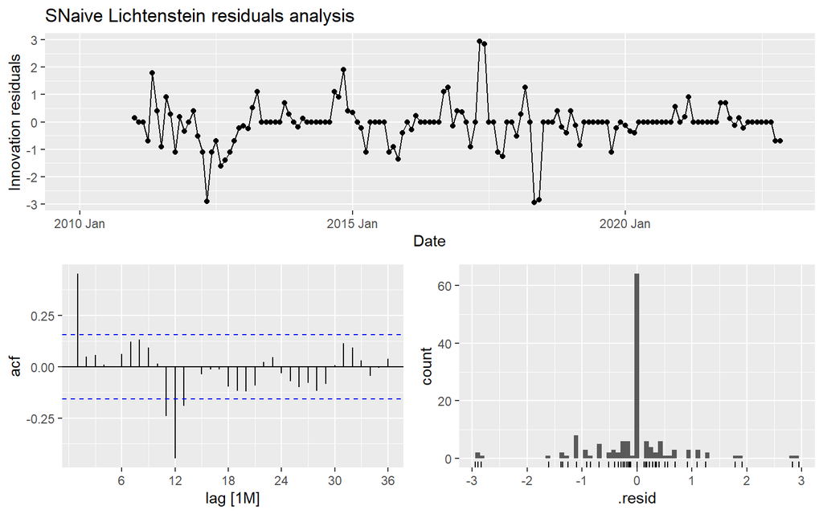

```r
#Checking the residuals before forecasting
n_Licht %>% gg_tsresiduals(lag_max = 36) + labs(title = "SNaive Lichtenstein residuals analysis")
```

### **Graphing the forecast**

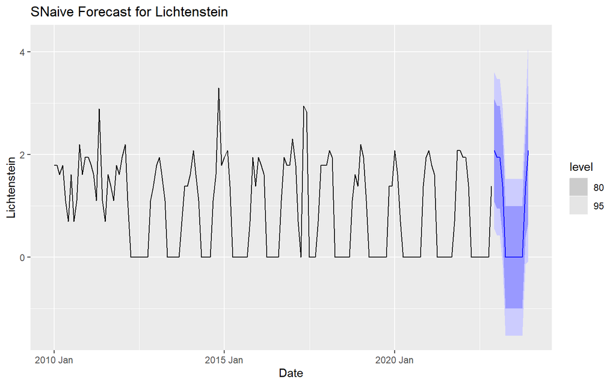

```r
# Graphing the forecast
n_Licht %>% forecast(h = 13) %>% autoplot(lich_log_2010_2022) +
  labs(title = "SNaive Forecast for Lichtenstein")
```

```r
#Extracting the forecasted values
forecast_table_Lichtenstein_n <- data.frame(Model = c("SNaive"),
                              Forecast_Values = c(forecast_n_Licht))

forecast_table_Lichtenstein_n <- forecast_table_Lichtenstein_n %>% select(Forecast_Values.Date,Forecast_Values..mean, Forecast_Values.90.)
forecast_table_Lichtenstein_n$Country <- "Lichtenstein"

colnames(forecast_table_Lichtenstein_n)[1] <- "Month"
colnames(forecast_table_Lichtenstein_n)[2] <- "PF"
colnames(forecast_table_Lichtenstein_n)[3] <- "CI"
```

### **Forecast Table**

The resulting forecast table for Lichtenstein is shown below.

```r
#forecast_table_Lichtenstein_n
kbl(forecast_table_Lichtenstein_n) %>%
  kable_styling(fixed_thead = T)
```

| Month | PF | CI | Country |
| --- | --- | --- | --- |
| 2022 Dec | 2.079442 | [0.7999965, 3.358887]90 | Lichtenstein |
| 2023 Jan | 1.945910 | [0.6664651, 3.225355]90 | Lichtenstein |
| 2023 Feb | 1.945910 | [0.6664651, 3.225355]90 | Lichtenstein |
| 2023 Mar | 1.386294 | [0.1068493, 2.665739]90 | Lichtenstein |
| 2023 Apr | 0.000000 | [-1.2794450, 1.279445]90 | Lichtenstein |
| 2023 May | 0.000000 | [-1.2794450, 1.279445]90 | Lichtenstein |
| 2023 Jun | 0.000000 | [-1.2794450, 1.279445]90 | Lichtenstein |
| 2023 Jul | 0.000000 | [-1.2794450, 1.279445]90 | Lichtenstein |
| 2023 Aug | 0.000000 | [-1.2794450, 1.279445]90 | Lichtenstein |
| 2023 Sep | 0.000000 | [-1.2794450, 1.279445]90 | Lichtenstein |
| 2023 Oct | 0.000000 | [-1.2794450, 1.279445]90 | Lichtenstein |
| 2023 Nov | 1.386294 | [0.1068493, 2.665739]90 | Lichtenstein |
| 2023 Dec | 2.079442 | [0.2700330, 3.888850]90 | Lichtenstein |

## 5.6 Total

We fit Total electricity demand data using the ARIMA model.

```r
# Modelling ETS automatically
arima_total <- data_elec %>%
  select(Total) %>%
  model(ARIMA(Total))

# Forecasting using the models
forecast_arima_total <- arima_total %>% forecast(h = 13) %>% hilo(90)
```

### **Checking Residuals**

The output below suggests that the ARIMA model did well in capturing all the dynamics in data, as the residuals seem to be white noise.

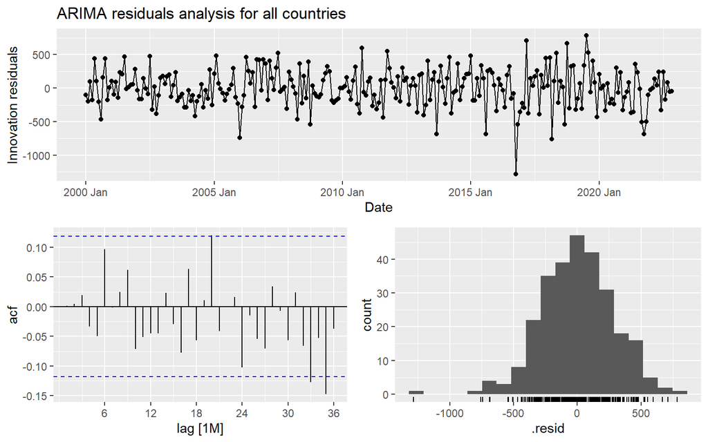

```r
arima_total %>% gg_tsresiduals(lag_max = 36) + labs(title = "ARIMA residuals analysis for all countries")
```

### **Graphing the forecast**

For better visualization, we plot our forecast results starting from 2015.

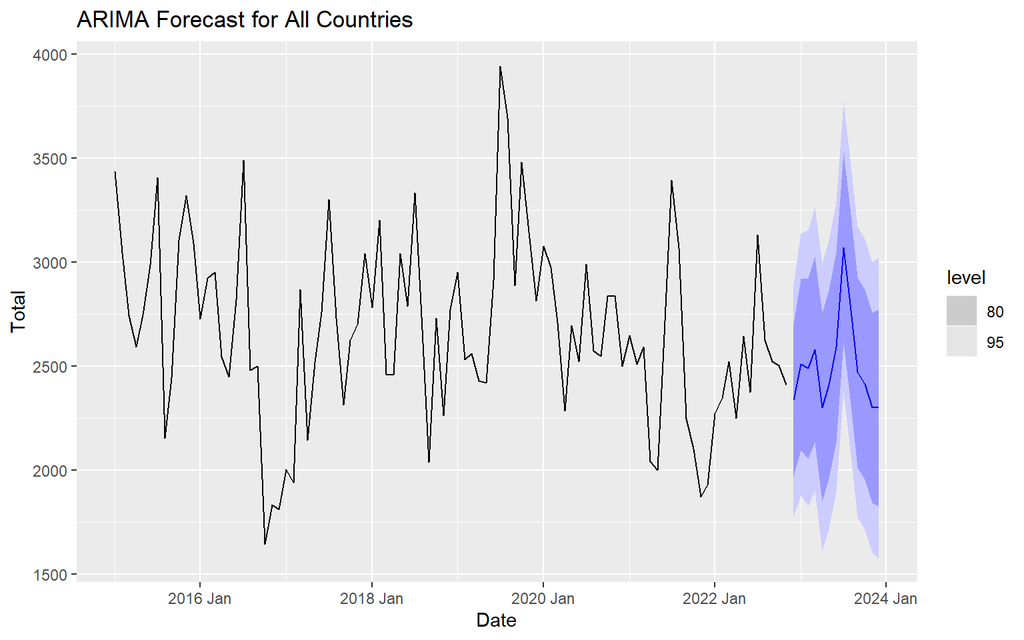

```r
arima_total %>% forecast(h = 13) %>% autoplot(Total_since_2015) +
  labs(title = "ARIMA Forecast for All Countries")
```

```r
#Extracting the forecasted values
forecast_table_total_a<- data.frame(Model = c("ARIMA"),
                          Forecast_Values = c(forecast_arima_total))

forecast_table_total_a <- forecast_table_total_a %>% select(Forecast_Values.Date,Forecast_Values..mean, Forecast_Values.90.)
forecast_table_total_a$Country <- "Total"

colnames(forecast_table_total_a)[1] <- "Month"
colnames(forecast_table_total_a)[2] <- "PF"
colnames(forecast_table_total_a)[3] <- "CI"
```

### **Forecast Table**

The resulting forecast table for Total is shown below.

```r
#forecast_table_total_a
kbl(forecast_table_total_a) %>%
  kable_styling(fixed_thead = T)
```

| Month | PF | CI | Country |
| --- | --- | --- | --- |
| 2022 Dec | 2336.515 | [1867.508, 2805.521]90 | Total |
| 2023 Jan | 2507.818 | [1979.592, 3036.043]90 | Total |
| 2023 Feb | 2489.217 | [1932.451, 3045.983]90 | Total |
| 2023 Mar | 2580.353 | [2009.191, 3151.514]90 | Total |
| 2023 Apr | 2302.442 | [1723.875, 2881.008]90 | Total |
| 2023 May | 2411.328 | [1828.916, 2993.740]90 | Total |
| 2023 Jun | 2591.927 | [2007.509, 3176.345]90 | Total |
| 2023 Jul | 3070.838 | [2485.371, 3656.306]90 | Total |
| 2023 Aug | 2798.490 | [2212.473, 3384.507]90 | Total |
| 2023 Sep | 2469.884 | [1883.579, 3056.189]90 | Total |
| 2023 Oct | 2412.024 | [1825.569, 2998.480]90 | Total |
| 2023 Nov | 2300.391 | [1713.856, 2886.926]90 | Total |
| 2023 Dec | 2299.457 | [1694.028, 2904.886]90 | Total |

## Combining all forecasts into one table:

Below is the final table containing `Country`, `Month`,`Point.Forecast`, and the 90% lower and upper bounds `Upper.Interval` and `Lower.Interval`.

For Lichtenstein, since we logged the data to make the forecasts earlier, we have used its inverse function (exponent) to bring the values back to their original magnitude.

```r
final_fc <- bind_rows(forecast_table_germany_e, forecast_table_italy_a, forecast_table_france_e, forecast_table_austria_e,forecast_table_Lichtenstein_n, forecast_table_total_a)

#Rounding all values to 0 significant figures because at the moment they have 4 decimals each...
final_fc$PF <- round(final_fc$PF)
final_fc$CI <- round(final_fc$CI)

#Removing all non-negative values from the CI column and replacing them by 0 - With string manipulation bc i can't find another way
final_fc$CI <- str_replace(final_fc$CI, "\\[(-\\d+),", "[0,")


# creating lower and upper bound
lower_str_fc <- gsub("\\[(.*),.*\\]90", "\\1", final_fc$CI)
upper_str_fc <- gsub("\\[.*, (.*)\\]90", "\\1", final_fc$CI)

# Converting to numeric values
lower_bound <- as.numeric(lower_str_fc)
upper_bound <- as.numeric(upper_str_fc)

# Creating the data frame
Correct_final_fc <- data.frame("Country" = final_fc$Country,
                             "Month" = final_fc$Month,
                             "Point Forecast" = final_fc$PF,
                             "Lower Interval" = lower_bound,
                             "Upper Interval" = upper_bound)


Correct_final_fc <- Correct_final_fc %>%
  mutate(
    Point.Forecast = ifelse(Country == "Lichtenstein" & Point.Forecast != 0, exp(Point.Forecast), Point.Forecast),
    Lower.Interval = ifelse(Country == "Lichtenstein" & Point.Forecast != 0, exp(Lower.Interval), Lower.Interval),
    Upper.Interval = ifelse(Country == "Lichtenstein" & Point.Forecast != 0, exp(Upper.Interval), Upper.Interval)
  )


#Rounding the values again
Correct_final_fc$Point.Forecast <- round(Correct_final_fc$Point.Forecast)
Correct_final_fc$Lower.Interval <- round(Correct_final_fc$Lower.Interval)
Correct_final_fc$Upper.Interval <- round(Correct_final_fc$Upper.Interval)

# Printing the adjusted output
#print(Correct_final_fc)

kbl(cbind(Correct_final_fc)) %>%
  kable_paper() %>%
  scroll_box(width = "100%", height = "500px")
```

| Country | Month | Point.Forecast | Lower.Interval | Upper.Interval |
| --- | --- | --- | --- | --- |
| Germany | 2022 Dec | 157 | 69 | 245 |
| Germany | 2023 Jan | 134 | 38 | 230 |
| Germany | 2023 Feb | 105 | 16 | 194 |
| Germany | 2023 Mar | 133 | 4 | 263 |
| Germany | 2023 Apr | 273 | 0 | 569 |
| Germany | 2023 May | 490 | 0 | 1077 |
| Germany | 2023 Jun | 429 | 0 | 991 |
| Germany | 2023 Jul | 429 | 0 | 1036 |
| Germany | 2023 Aug | 398 | 0 | 1004 |
| Germany | 2023 Sep | 282 | 0 | 741 |
| Germany | 2023 Oct | 218 | 0 | 596 |
| Germany | 2023 Nov | 177 | 0 | 501 |
| Germany | 2023 Dec | 156 | 0 | 460 |
| Italy | 2022 Dec | 1827 | 1290 | 2363 |
| Italy | 2023 Jan | 1831 | 1164 | 2497 |
| Italy | 2023 Feb | 2084 | 1310 | 2859 |
| Italy | 2023 Mar | 2065 | 1195 | 2935 |
| Italy | 2023 Apr | 1763 | 808 | 2718 |
| Italy | 2023 May | 1826 | 792 | 2860 |
| Italy | 2023 Jun | 1931 | 824 | 3037 |
| Italy | 2023 Jul | 2272 | 1097 | 3447 |
| Italy | 2023 Aug | 1979 | 739 | 3219 |
| Italy | 2023 Sep | 1936 | 635 | 3237 |
| Italy | 2023 Oct | 1939 | 579 | 3299 |
| Italy | 2023 Nov | 1907 | 491 | 3323 |
| Italy | 2023 Dec | 1816 | 288 | 3344 |
| France | 2022 Dec | 453 | 86 | 819 |
| France | 2023 Jan | 426 | 78 | 775 |
| France | 2023 Feb | 356 | 62 | 650 |
| France | 2023 Mar | 268 | 45 | 492 |
| France | 2023 Apr | 233 | 37 | 429 |
| France | 2023 May | 217 | 32 | 401 |
| France | 2023 Jun | 337 | 48 | 626 |
| France | 2023 Jul | 454 | 61 | 848 |
| France | 2023 Aug | 412 | 52 | 772 |
| France | 2023 Sep | 390 | 46 | 734 |
| France | 2023 Oct | 351 | 38 | 664 |
| France | 2023 Nov | 372 | 38 | 706 |
| France | 2023 Dec | 453 | 42 | 863 |
| Austria | 2022 Dec | 109 | 46 | 173 |
| Austria | 2023 Jan | 106 | 37 | 176 |
| Austria | 2023 Feb | 103 | 27 | 178 |
| Austria | 2023 Mar | 102 | 22 | 183 |
| Austria | 2023 Apr | 112 | 26 | 198 |
| Austria | 2023 May | 123 | 32 | 213 |
| Austria | 2023 Jun | 126 | 31 | 220 |
| Austria | 2023 Jul | 148 | 49 | 247 |
| Austria | 2023 Aug | 148 | 44 | 251 |
| Austria | 2023 Sep | 112 | 5 | 219 |
| Austria | 2023 Oct | 111 | 0 | 222 |
| Austria | 2023 Nov | 108 | 0 | 222 |
| Austria | 2023 Dec | 109 | 0 | 227 |
| Lichtenstein | 2022 Dec | 7 | 3 | 20 |
| Lichtenstein | 2023 Jan | 7 | 3 | 20 |
| Lichtenstein | 2023 Feb | 7 | 3 | 20 |
| Lichtenstein | 2023 Mar | 3 | 1 | 20 |
| Lichtenstein | 2023 Apr | 0 | 0 | 1 |
| Lichtenstein | 2023 May | 0 | 0 | 1 |
| Lichtenstein | 2023 Jun | 0 | 0 | 1 |
| Lichtenstein | 2023 Jul | 0 | 0 | 1 |
| Lichtenstein | 2023 Aug | 0 | 0 | 1 |
| Lichtenstein | 2023 Sep | 0 | 0 | 1 |
| Lichtenstein | 2023 Oct | 0 | 0 | 1 |
| Lichtenstein | 2023 Nov | 3 | 1 | 20 |
| Lichtenstein | 2023 Dec | 7 | 1 | 55 |
| Total | 2022 Dec | 2337 | 1868 | 2806 |
| Total | 2023 Jan | 2508 | 1980 | 3036 |
| Total | 2023 Feb | 2489 | 1932 | 3046 |
| Total | 2023 Mar | 2580 | 2009 | 3152 |
| Total | 2023 Apr | 2302 | 1724 | 2881 |
| Total | 2023 May | 2411 | 1829 | 2994 |
| Total | 2023 Jun | 2592 | 2008 | 3176 |
| Total | 2023 Jul | 3071 | 2485 | 3656 |
| Total | 2023 Aug | 2798 | 2212 | 3385 |
| Total | 2023 Sep | 2470 | 1884 | 3056 |
| Total | 2023 Oct | 2412 | 1826 | 2998 |
| Total | 2023 Nov | 2300 | 1714 | 2887 |
| Total | 2023 Dec | 2299 | 1694 | 2905 |

```r
#str(Correct_final_fc)

library(writexl)

# Export the table to Excel
write_xlsx(Correct_final_fc, "finalforecast.xlsx")
```

# 6. Challenges and Further Analysis

In this section we will comment on things didn’t go so well in our analysis, and things that could be improved.

Firstly, in the confidence bounds, some of Germany’s, Lichtenstein’s and Austria’s lower bound values were negative at the 90% confidence intervals, which you can actually see in the graphs of the forecasts for each country. This was a problem because electricity exports can’t physically be negative, and the lowest value they can take is zero. This happened because when fitting the models, we didn’t specify that the forecasts shouldn’t take negative values, and obviously the models can’t know that themselves. To solve this issue, we decided to manually set the lower bounds of these confidence intervals to 0 as it wouldn’t make any sense for them to be negative, however we do have to mention that by doing so, the confidence intervals we show are not 90% intervals.

Secondly, we decided not to add any covariates to our models, and only used the historical data we were given. Covariates could potentially help our forecasts be more accurate, as they can capture patterns and the effects of external factors which have an impact on electricity demand. An example of such a factor could be monthly average temperature values, because temperature probably plays a big role in energy consumption at the national level. Another example of a factor we could have included in our analysis would be the average hours of sunlight, because people tend to use more energy to light up their house in the winter compared to the summer. Another factor could be the implementation and use of different forms of energy, such as wind energy/nuclear energy to supply power inside a country, rather than simply importing it from Switzerland.

# Appendix

## *Appendix 1. Decomposition Comparison*

- Classical Decomposition assumes seasonal component repeats from year to year, which usually is not the case in reality, over smoothes rapid rises (is not recommended to use, but still…).
- STL Decomposition is a versatile and robust method that handles any seasonality; seasonal components can change, and smoothness can be controlled.
- X-11 method originated in the US Census Bureau and was further developed by Statistics Canada, based on classical decomposition, a slightly improved version of classical decomposition; the seasonal component varies slowly over time, highly robust to outliers and level shifts in the time series.

## *Appendix 2. Accuracy metrics comparison*

*AIC* criteria are used to assess the goodness of fit of a model, with lower values indicating a better fit. *RMSE* and MAE are used to measure the difference between predicted values and actual values. Comparatively lower numbers of these metrics assume a better model’s forecast quality potential.

## *Appendix 3. Plots of all countries’ historical data*

### **Germany**

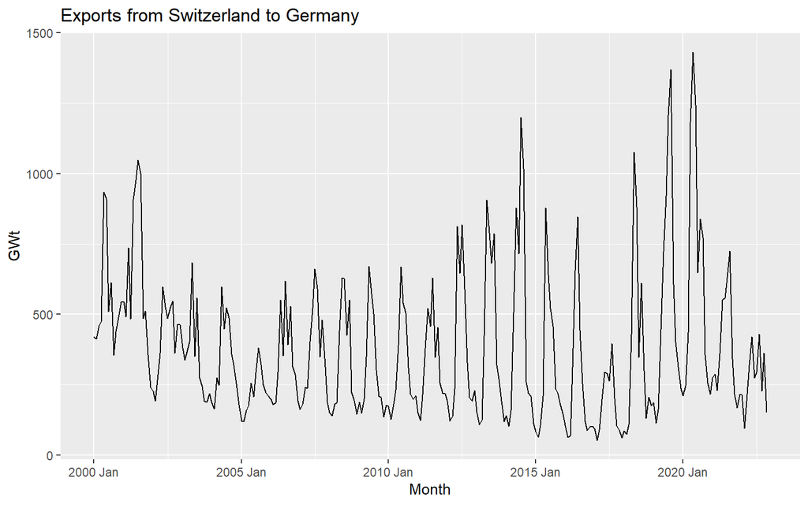

```r
data_elec %>% autoplot(Germany) +
  ggtitle("Exports from Switzerland to Germany") +
  ylab("GWt") + xlab("Month")
```

### **France**

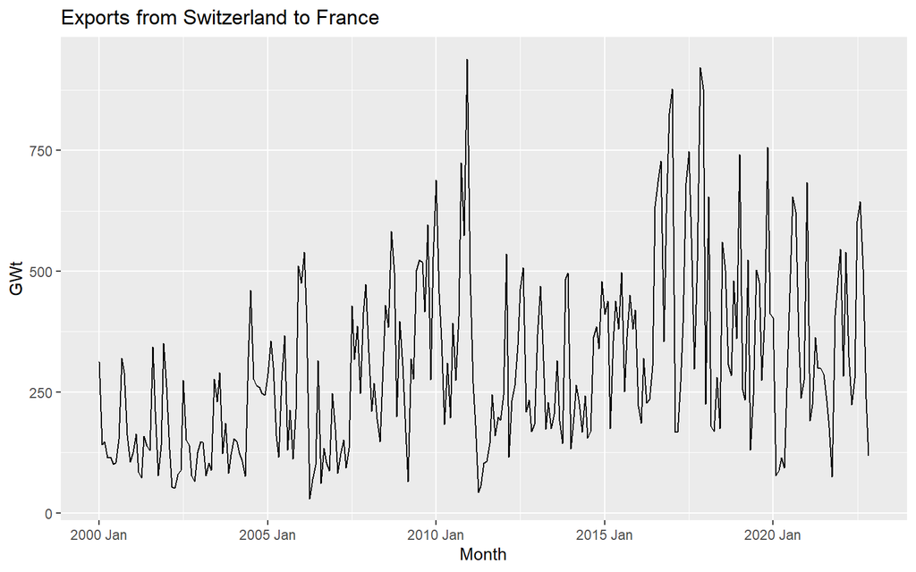

```r
data_elec %>% autoplot(France) +
  ggtitle("Exports from Switzerland to France") +
  ylab("GWt") + xlab("Month")
```

### **Italy**

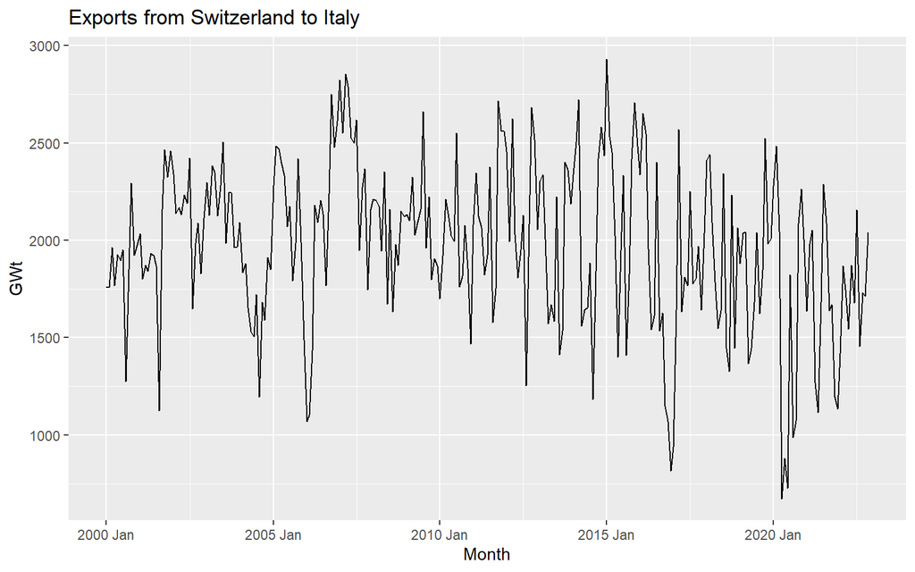

```r
data_elec %>% autoplot(Italy) +
  ggtitle("Exports from Switzerland to Italy") +
  ylab("GWt") + xlab("Month")
```

### **Austria**

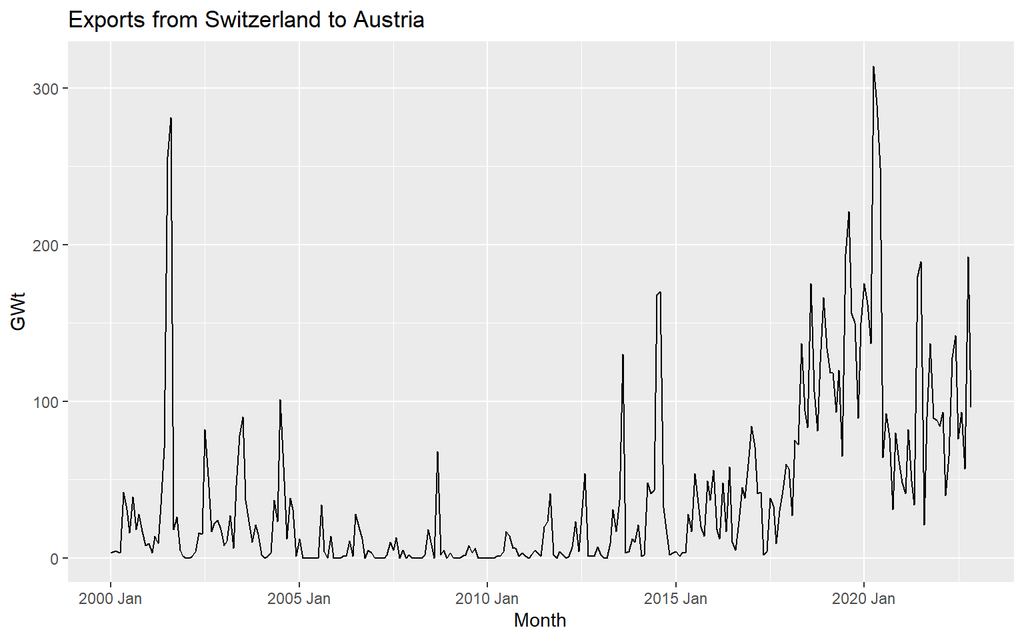

```r
data_elec %>% autoplot(Austria) +
  ggtitle("Exports from Switzerland to Austria") +
  ylab("GWt") + xlab("Month")
```

### **Lichtenstein**

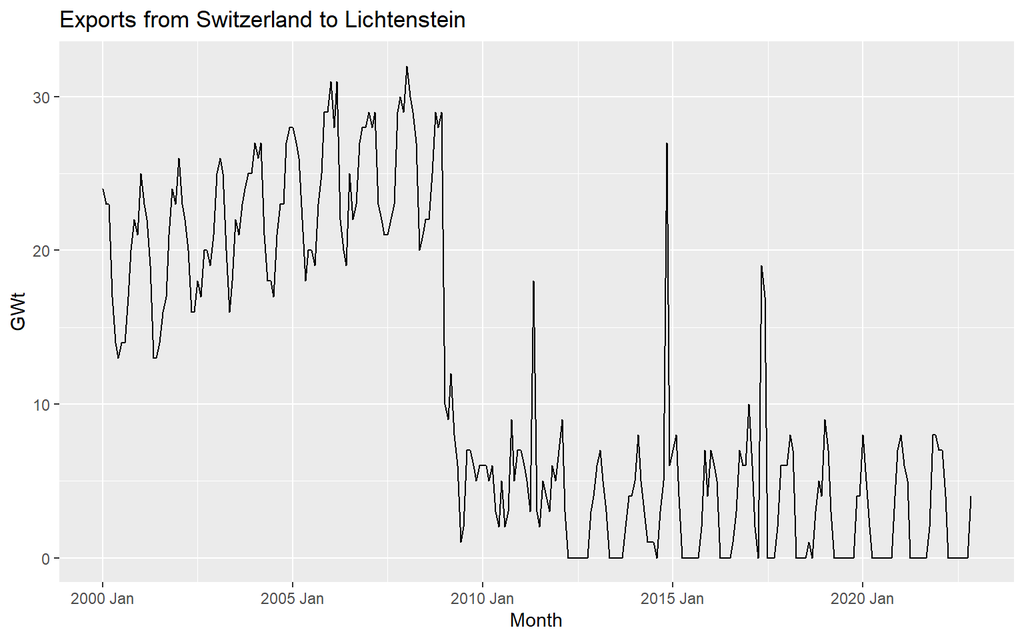

```r
data_elec %>% autoplot(Lichtenstein) +
  ggtitle("Exports from Switzerland to Lichtenstein") +
  ylab("GWt") + xlab("Month")
```

### **Total**

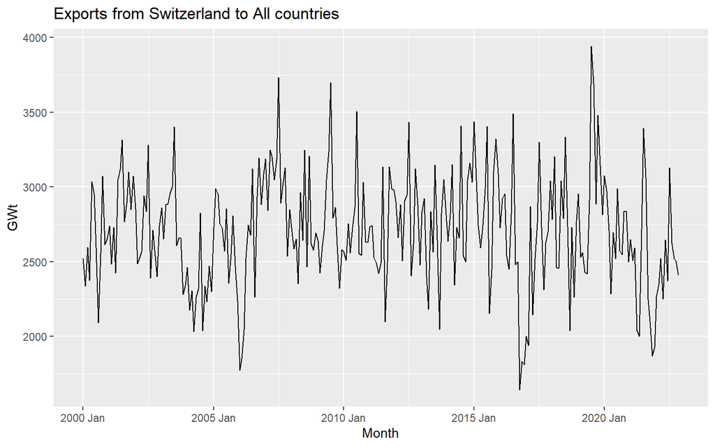

```r
data_elec %>% autoplot(Total) +
  ggtitle("Exports from Switzerland to All countries") +
  ylab("GWt") + xlab("Month")
```

## *Appendix 4. Plots of Seasonal Subseries*

### **Germany**

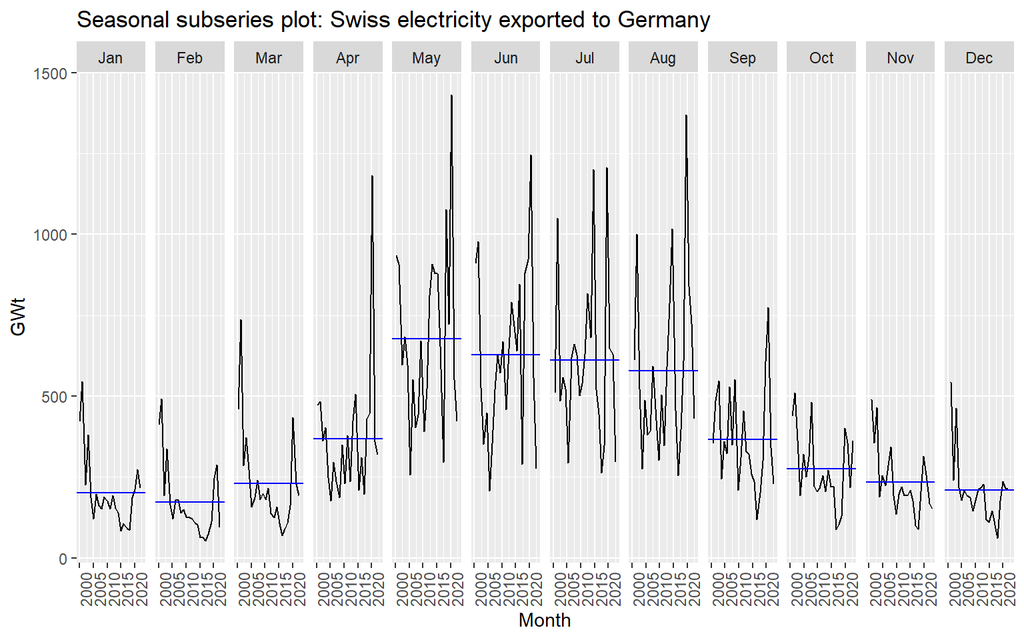

```r
data_elec %>% gg_subseries(Germany) +
    ylab("GWt") + xlab("Month") +
    ggtitle("Seasonal subseries plot: Swiss electricity exported to Germany")
```

### **France**

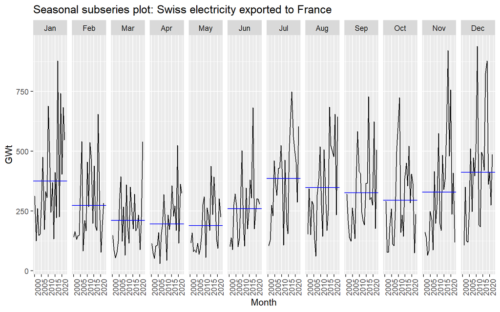

```r
data_elec %>% gg_subseries(France) +
    ylab("GWt") + xlab("Month") +
    ggtitle("Seasonal subseries plot: Swiss electricity exported to France")
```

### **Italy**

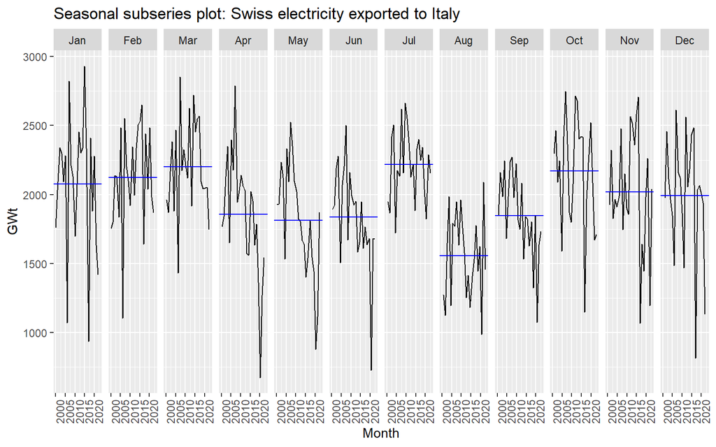

```r
data_elec %>% gg_subseries(Italy) +
    ylab("GWt") + xlab("Month") +
    ggtitle("Seasonal subseries plot: Swiss electricity exported to Italy")
```

### **Austria**

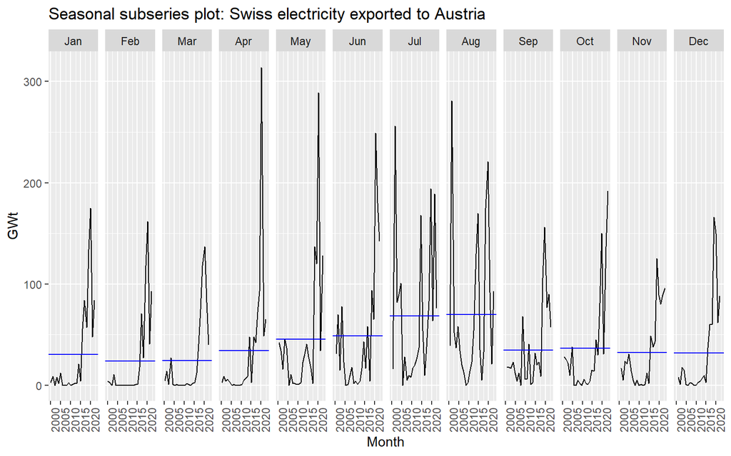

```r
data_elec %>% gg_subseries(Austria) +
    ylab("GWt") + xlab("Month") +
    ggtitle("Seasonal subseries plot: Swiss electricity exported to Austria")
```

### **Lichtenstein**

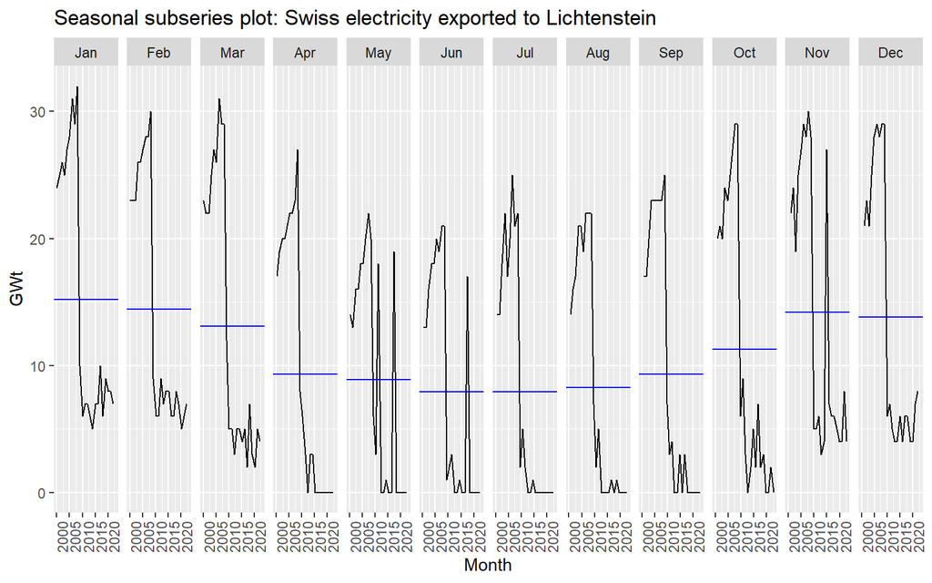

```r
data_elec %>% gg_subseries(Lichtenstein) +
    ylab("GWt") + xlab("Month") +
    ggtitle("Seasonal subseries plot: Swiss electricity exported to Lichtenstein")
```

### **Total**

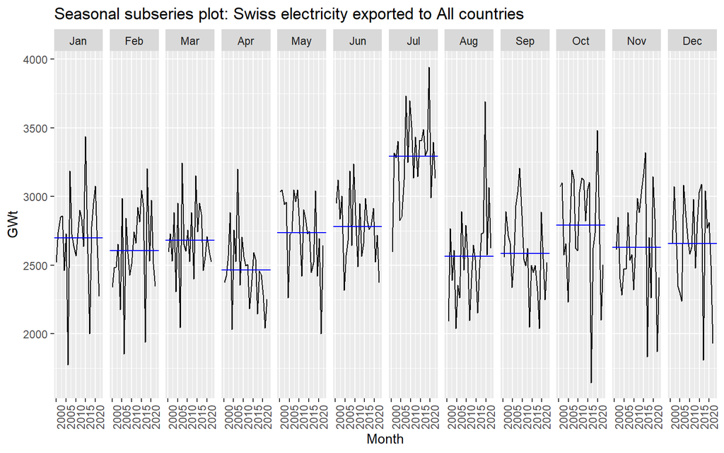

```r
data_elec %>% gg_subseries(Total) +
    ylab("GWt") + xlab("Month") +
    ggtitle("Seasonal subseries plot: Swiss electricity exported to All countries")
```